# Regressors analysys

Spartak Bughdaryan

11/29/2019

# Content

- About data
- Analysys
- Hyper parameters
- Conclusion

## About data

For data I generated 3000 points, I took some covariance matrix, computed eiganvalues and eiganvectors of that matrix, and with normalized random Xs calculated Ys. You can view it in `generate_data.py` for more detail. So overall generated 3 files (see plots above).

The first data.

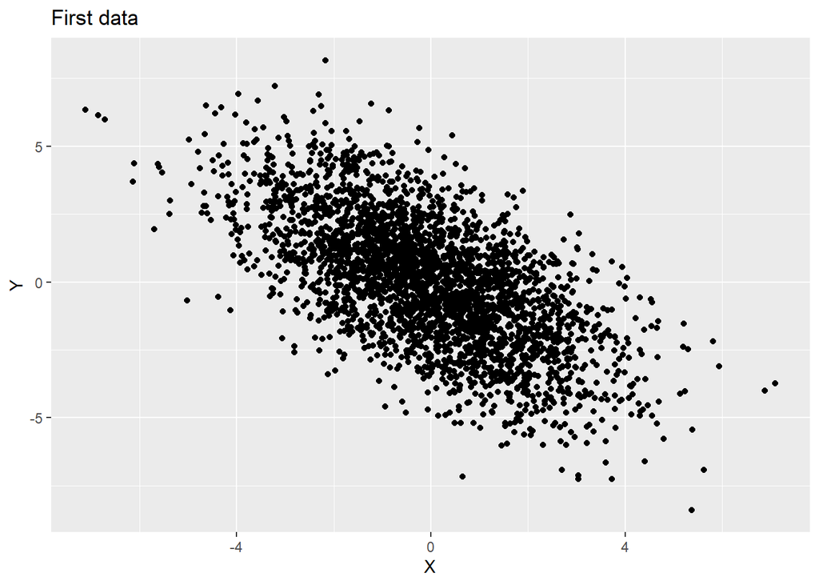

```r
df1 <- read.csv('data/1.csv')
df1$X.1 <- NULL

df1 %>% ggplot(aes(X,Y)) + geom_point() + labs(title = "First data")
```

The second data.

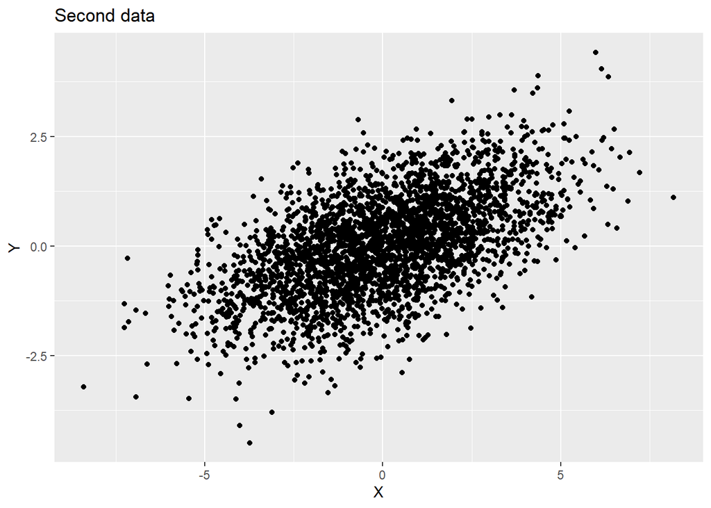

```r
df2 <- read.csv('data/2.csv')
df2$X.1 <- NULL

df2 %>% ggplot(aes(X,Y)) + geom_point() + labs(title = "Second data")
```

And third.

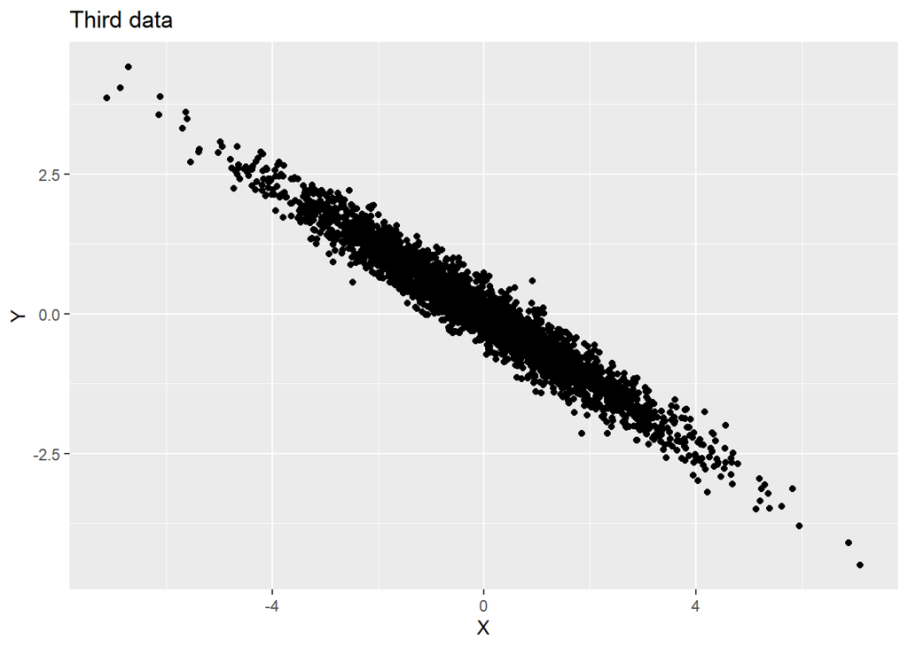

```r
df3 <- read.csv('data/3.csv')
df3$X.1 <- NULL

df3 %>% ggplot(aes(X,Y)) + geom_point() + labs(title = "Third data")
```

Here we have different cases with different corelation between X and Y. We will see differences between data and overall analysys.

## Analysys

Lets start from first dataset named `df1` and see histogram and density plot of regressors after 1000 random samples with 500 sample size

Here we iterate `iter_count` times, and each time calculate linear model for sample, save coeficients, variation and mean

```r
iter_count <- 1000
sample_size <- 500
df1_bs = data.frame(b0 = numeric(), b1=numeric(), var=numeric(), mean.X = numeric(), mean.Y = numeric(), iter_count = numeric())
set.seed(1)
for (i in 1:iter_count) {
  df_sample <- sample_n(df1, sample_size)
  model <- lm(Y~X, df_sample)

  b0 <- coef(model)[1]
  b1 <- coef(model)[2]

  df1_bs <- rbind(df1_bs, data.frame(b0 = c(b0), b1 = c(b1),mean.X=mean(df_sample$X), mean.Y = mean(df_sample$Y), var=var(df_sample)))
}

head(df1_bs)
```

```
##            b0         b1      mean.X       mean.Y     var.X     var.Y
## 1 -0.09854878 -0.7709704  0.06945077 -0.152093272  3.656498 -2.819052
## 2 -0.09854878 -0.7709704  0.06945077 -0.152093272 -2.819052  5.917123
## 3 -0.02565257 -0.7793044 -0.02778721 -0.003997877  3.456956 -2.694021
## 4 -0.02565257 -0.7793044 -0.02778721 -0.003997877 -2.694021  5.452876
## 5 -0.11653956 -0.8290988 -0.06327993 -0.064074251  3.631995 -3.011283
## 6 -0.11653956 -0.8290988 -0.06327993 -0.064074251 -3.011283  5.757901
```

And the histogram

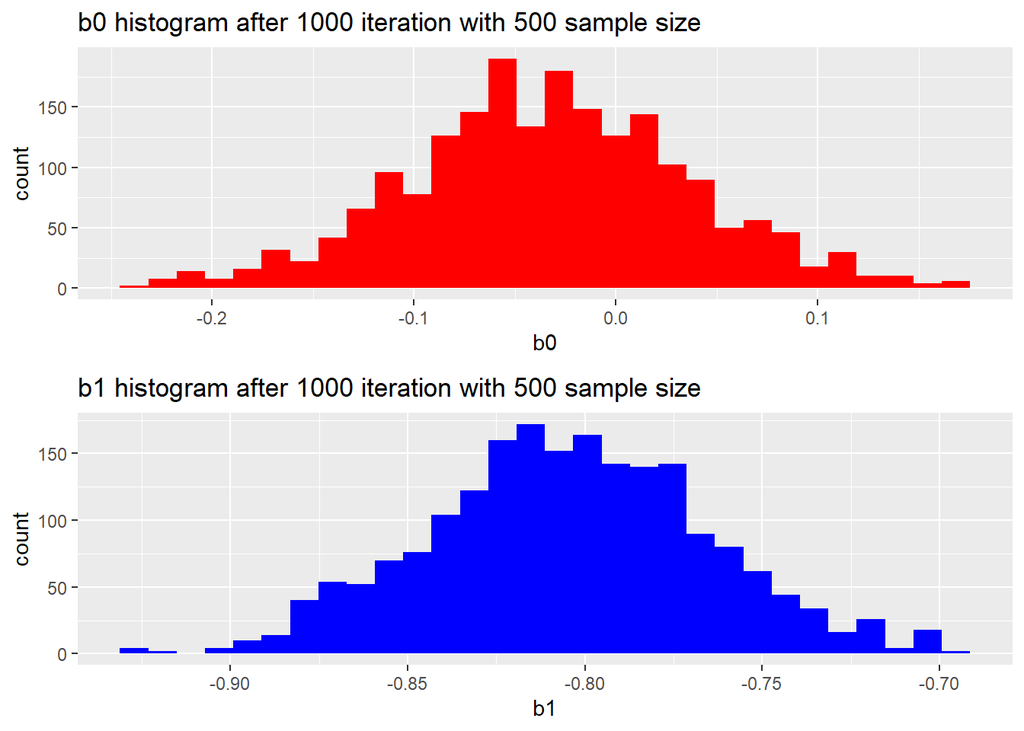

```r
grid.arrange(
  df1_bs %>% ggplot(aes(b0)) + geom_histogram(fill='red') + labs(xlab="b0", ylab="count", title="b0 histogram after 1000 iteration with 500 sample size"),
  df1_bs %>% ggplot(aes(b1)) + geom_histogram(fill='blue') + labs(xlab="b1", ylab="count", title="b1 histogram after 1000 iteration with 500 sample size")
)
```

We can also take a look at density plots

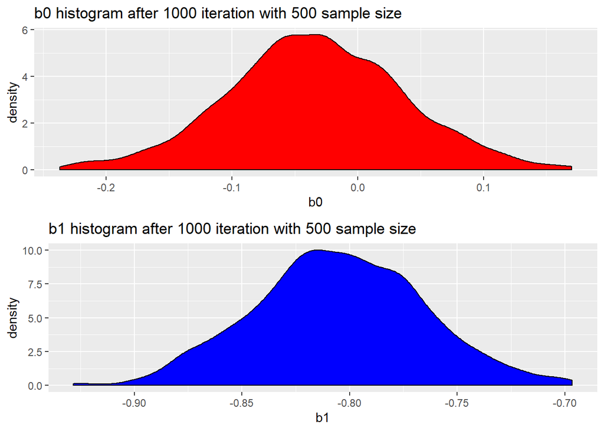

```r
df1_b0_plot <- df1_bs %>% ggplot(aes(b0)) +
  geom_density(fill='red') +
  labs(xlab="b0", ylab="count", title="b0 histogram after 1000 iteration with 500 sample size")
df1_b1_plot <- df1_bs %>% ggplot(aes(b1)) +
  geom_density(fill='blue') +
  labs(xlab="b1", ylab="count", title="b1 histogram after 1000 iteration with 500 sample size")

grid.arrange(
  df1_b0_plot,
  df1_b1_plot
)
```

They both look pretty much normal distributions, now lets calculate linear model for whole `df1` and see if they are equal

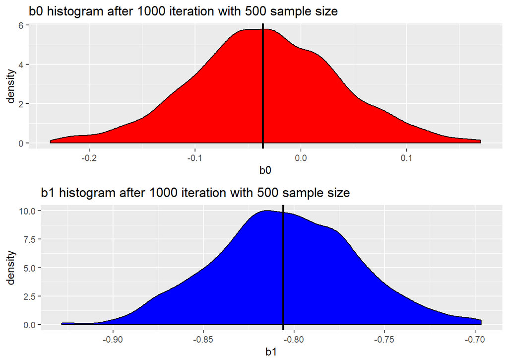

```r
model <- lm(Y~X, df1)

df1_b0 <- coef(model)[1]
df1_b1 <- coef(model)[2]

grid.arrange(
  df1_b0_plot + geom_vline(xintercept = df1_b0, color='black', size=1),
  df1_b1_plot + geom_vline(xintercept = df1_b1, color='black', size=1)
)
```

As we can see, the actual $`b_0`$ and $`b_1`$ are in the middle of both plots, now lets do some hypothesis testing for $b_0$ and $b_1$

1. $H_{0}: df_1.b_0 = b_0$, $H_{A}: df_1.b_0 \ne b_0$
2. $H_{0}: df_1.b_1 = b_1$, $H_{A}: df_1.b_1 \ne b_1$

```r
set.seed(1)
t.test(x=df1_bs$b0, mu=df1_b0)
```

```
##
##  One Sample t-test
##
## data:  df1_bs$b0
## t = 1.6277, df = 1999, p-value = 0.1038
## alternative hypothesis: true mean is not equal to -0.03600886
## 95 percent confidence interval:
##  -0.03653174 -0.03038172
## sample estimates:
##   mean of x
## -0.03345673
```

As we can see, p-value for $b_0$ is greather than $0.05$ so we cannot reject for $b_0$

```r
set.seed(1)
t.test(x=df1_bs$b1, mu=df1_b1)
```

```
##
##  One Sample t-test
##
## data:  df1_bs$b1
## t = 1.3135, df = 1999, p-value = 0.1891
## alternative hypothesis: true mean is not equal to -0.8060082
## 95 percent confidence interval:
##  -0.8065750 -0.8031425
## sample estimates:
##  mean of x
## -0.8048587
```

And same for $b_1$, we cannot reject it.

We can also do same process for $df_2$ and $df_3$, I will repeat the process and skip the explanation part just not to bore you.

```r
iter_count <- 1000
sample_size <- 500
df2_bs = data.frame(b0 = numeric(), b1=numeric(), var=numeric(), mean.X = numeric(), mean.Y = numeric(), iter_count = numeric())
df3_bs = data.frame(b0 = numeric(), b1=numeric(), var=numeric(), mean.X = numeric(), mean.Y = numeric(), iter_count = numeric())
set.seed(1)
for (i in 1:iter_count) {
  df_sample <- sample_n(df2, sample_size)
  model <- lm(Y~X, df_sample)

  b0 <- coef(model)[1]
  b1 <- coef(model)[2]

  df2_bs <- rbind(df2_bs, data.frame(b0 = c(b0), b1 = c(b1),mean.X=mean(df_sample$X), mean.Y = mean(df_sample$Y), var=var(df_sample)))



  df_sample <- sample_n(df3, sample_size)
  model <- lm(Y~X, df_sample)

  b0 <- coef(model)[1]
  b1 <- coef(model)[2]

  df3_bs <- rbind(df3_bs, data.frame(b0 = c(b0), b1 = c(b1),mean.X=mean(df_sample$X), mean.Y = mean(df_sample$Y), var=var(df_sample)))
}

model <- lm(Y~X, df2)

df2_b0 <- coef(model)[1]
df2_b1 <- coef(model)[2]

model <- lm(Y~X, df3)

df3_b0 <- coef(model)[1]
df3_b1 <- coef(model)[2]
```

Now we are done with calculation part, we can see the plots for each of them

Density plot for $df_2$

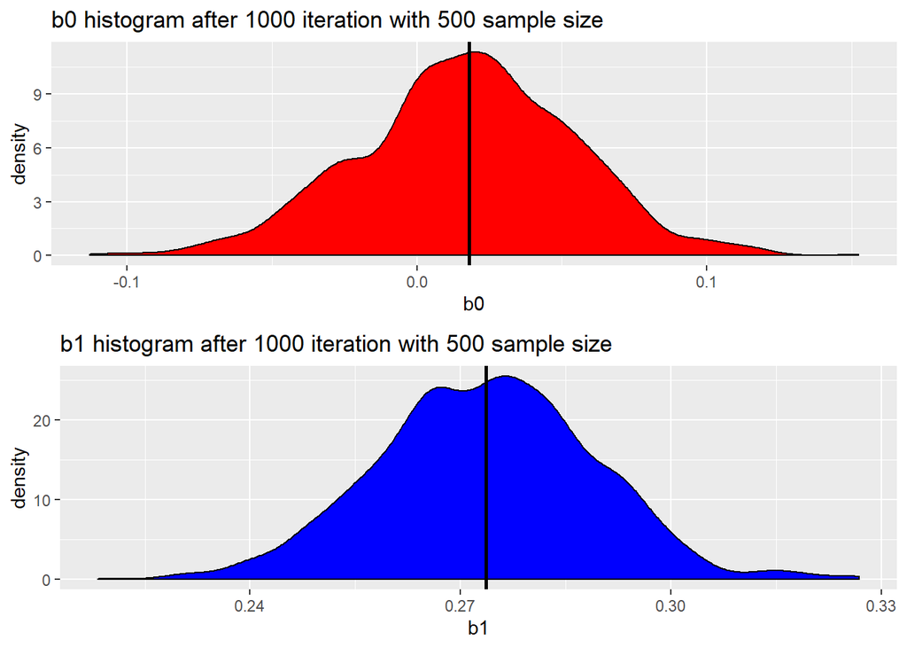

```r
df2_b0_plot <- df2_bs %>% ggplot(aes(b0)) +
  geom_density(fill='red') +
  labs(xlab="b0", ylab="count", title="b0 histogram after 1000 iteration with 500 sample size")
df2_b1_plot <- df2_bs %>% ggplot(aes(b1)) +
  geom_density(fill='blue') +
  labs(xlab="b1", ylab="count", title="b1 histogram after 1000 iteration with 500 sample size")

grid.arrange(
  df2_b0_plot + geom_vline(xintercept = df2_b0, color='black', size=1),
  df2_b1_plot + geom_vline(xintercept = df2_b1, color='black', size=1)
)
```

And also tests

For $b_0$

```r
set.seed(1)
t.test(x=df2_bs$b0, mu=df2_b0)
```

```
##
##  One Sample t-test
##
## data:  df2_bs$b0
## t = -0.8465, df = 1999, p-value = 0.3974
## alternative hypothesis: true mean is not equal to 0.0180463
## 95 percent confidence interval:
##  0.01571716 0.01897098
## sample estimates:
##  mean of x
## 0.01734407
```

And for $b_1$

```r
set.seed(1)
t.test(x=df2_bs$b1, mu=df2_b1)
```

```
##
##  One Sample t-test
##
## data:  df2_bs$b1
## t = 0.294, df = 1999, p-value = 0.7688
## alternative hypothesis: true mean is not equal to 0.2736038
## 95 percent confidence interval:
##  0.2730247 0.2743871
## sample estimates:
## mean of x
## 0.2737059
```

And for $df_3$

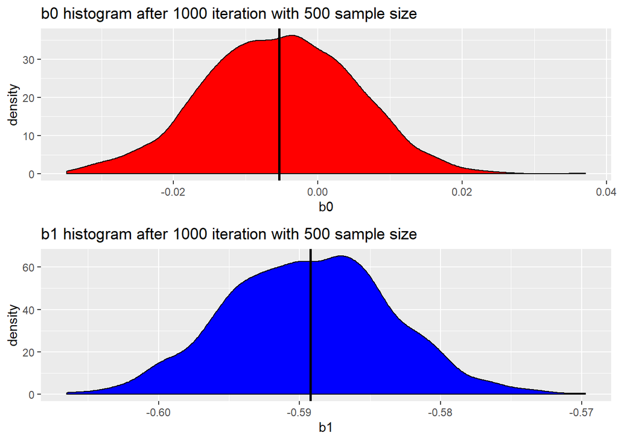

```r
df3_b0_plot <- df3_bs %>% ggplot(aes(b0)) +
  geom_density(fill='red') +
  labs(xlab="b0", ylab="count", title="b0 histogram after 1000 iteration with 500 sample size")
df3_b1_plot <- df3_bs %>% ggplot(aes(b1)) +
  geom_density(fill='blue') +
  labs(xlab="b1", ylab="count", title="b1 histogram after 1000 iteration with 500 sample size")

grid.arrange(
  df3_b0_plot + geom_vline(xintercept = df3_b0, color='black', size=1),
  df3_b1_plot + geom_vline(xintercept = df3_b1, color='black', size=1)
)
```

And tests

```r
set.seed(1)
t.test(x=df3_bs$b0, mu=df3_b0)
```

```
##
##  One Sample t-test
##
## data:  df3_bs$b0
## t = 0.1734, df = 1999, p-value = 0.8624
## alternative hypothesis: true mean is not equal to -0.005399799
## 95 percent confidence interval:
##  -0.005813688 -0.004905621
## sample estimates:
##    mean of x
## -0.005359655
```

And for $b_1$

```r
set.seed(1)
t.test(x=df3_bs$b1, mu=df3_b1)
```

```
##
##  One Sample t-test
##
## data:  df3_bs$b1
## t = -0.72662, df = 1999, p-value = 0.4675
## alternative hypothesis: true mean is not equal to -0.5892393
## 95 percent confidence interval:
##  -0.5895853 -0.5890803
## sample estimates:
##  mean of x
## -0.5893328
```

As we see, all our hypothesis had $p-value > \alpha = 0.05$ so we cannot reject any of them.

## Hyperparameters

One thing we can do is to change number of iterations and sample size, and see what we get

Lets start with number of iterations We can start with 10 iterations and multiply after each big iteration by some number

```r
iter_count <- 10
iter_count_multiplier <- c(10,10,10,5)
sample_size <- 500
bs = data.frame(b0 = numeric(), b1=numeric(),mean.X = numeric(), mean.Y=numeric(), var.X=numeric(),var.Y = numeric(), iter_count = numeric())
for (j in 1:length(iter_count_multiplier)) {
  set.seed(1)
  for (i in 1:iter_count) {
    df_sample <- sample_n(df1, sample_size)
    model <- lm(Y~X, df_sample)

    b0 <- coef(model)[1]
    b1 <- coef(model)[2]

    bs <- rbind(bs, data.frame(b0 = c(b0), b1 = c(b1),mean.X=mean(df_sample$X), mean.Y = mean(df_sample$Y), var.X=var(df_sample)[1,'X'], var.Y = var(df_sample)[2,'Y'], iter_count = c(iter_count)))
  }
  iter_count <- iter_count*iter_count_multiplier[j]
}
```

And now lets look at plots

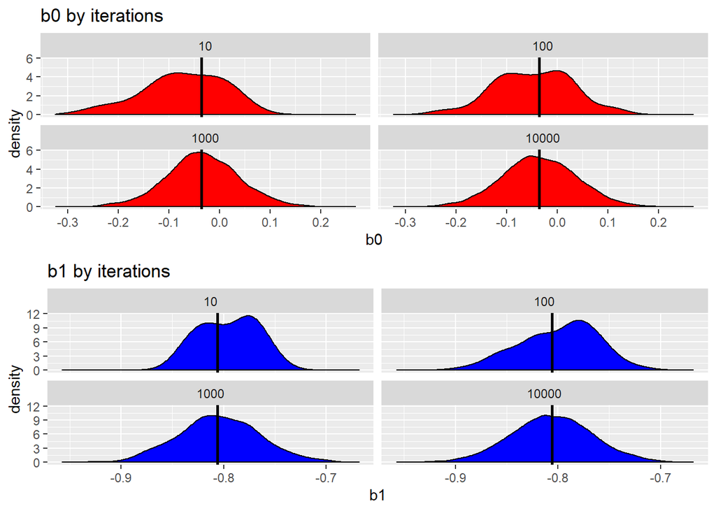

```r
grid.arrange(bs %>%
               ggplot(aes(b0)) +
               geom_density(fill='red') +
               geom_vline(xintercept = df1_b0, color='black', size=1) +
               facet_wrap(.~iter_count) +
               labs(title="b0 by iterations"),
             bs %>%
               ggplot(aes(b1)) +
               geom_density(fill='blue') +
               geom_vline(xintercept = df1_b1, color='black', size=1) +
               facet_wrap(.~iter_count)+
               labs(title="b1 by iterations"))
```

As we can see, after every $10^j$ iteration, it is becoming to look like normal distribution.

We also can see how variances and means are changed.

```r
bs %>% group_by(iter_count) %>% summarise(bs.mean.X = mean(mean.X), bs.mean.Y = mean(mean.Y), bs.var.X = mean(var.X), bs.var.Y = mean(var.Y)) %>% cbind(mean.X = mean(df1$X), mean.Y = mean(df1$Y), var.X=var(df1)[1,'X'],var.Y=var(df1)[2,'Y']) %>% select(iter_count, bs.mean.X, mean.X, bs.mean.Y, mean.Y, bs.var.X, var.X, bs.var.Y, var.Y)
```

```
##   iter_count   bs.mean.X     mean.X    bs.mean.Y       mean.Y bs.var.X
## 1         10 -0.03165606 -0.0368687 -0.046733973 -0.006292383 3.374715
## 2        100 -0.03108223 -0.0368687 -0.022127501 -0.006292383 3.433026
## 3       1000 -0.03585160 -0.0368687 -0.004540026 -0.006292383 3.438442
## 4      10000 -0.03565246 -0.0368687 -0.006592165 -0.006292383 3.433095
##     var.X bs.var.Y    var.Y
## 1 3.43048 5.417079 5.518823
## 2 3.43048 5.501491 5.518823
## 3 3.43048 5.519780 5.518823
## 4 3.43048 5.517890 5.518823
```

We can see that after each $10^j$ iteration mean and variation of sample is approaching to $df_1$s mean and variation.

## Conclusion

So far, we looked at histogram and density plots, after 1000 sample iterations which seemed to be normal,

we did hypothesis testing, after which we saw that for all dataframes $p-value > \alpha = 0.05$, so we couldn’t reject any hypothesis

we saw that density plot is becoming more normal after $10,10^2, 10^3, 10^4$ iterations,

we saw that mean and variation of sample is approaching to populations mean and variation,

and what we can conclude is that by increasing number of sample iteration, our sample is behaving like population `in average`, regressors of sample are aproaching to populations regressors `in average`.

I hope it wasn’t boring and You enjoy it. Thank you for reading.